# hw3t1

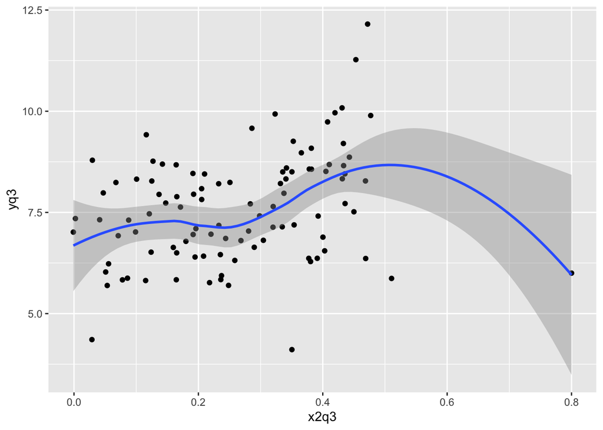

```r
Data_newq3_ = data.frame(x2q3,yq3)
ggplot(data=Data_newq3_, mapping = aes(x = x2q3, y = yq3)) + geom_point() + geom_smooth()
```

As seen from the plot the pointat x= 0.8 is a leverage point as its an extreme value with respect to other value of x.

```r
lregq3.1 <- lm(yq3 ~ x1q3)
summary(lregq3.1)
```

```
##
## Call:
## lm(formula = yq3 ~ x1q3)
##
## Residuals:
##     Min      1Q  Median      3Q     Max
## -3.8659 -0.8222  0.0638  0.6896  3.7514
##
## Coefficients:
##             Estimate Std. Error t value Pr(>|t|)
## (Intercept)   6.6108     0.2719  24.314  < 2e-16 ***
## x1q3          1.9158     0.4692   4.083 9.02e-05 ***
## ---
## Signif. codes:  0 '***' 0.001 '**' 0.01 '*' 0.05 '.' 0.1 ' ' 1
##
## Residual standard error: 1.264 on 99 degrees of freedom
## Multiple R-squared:  0.1441, Adjusted R-squared:  0.1355
## F-statistic: 16.67 on 1 and 99 DF,  p-value: 9.025e-05
```

```r
lregq3.2 <- lm(yq3 ~ x2q3)
summary(lregq3.2)
```

```
##
## Call:
## lm(formula = yq3 ~ x2q3)
##
## Residuals:
##     Min      1Q  Median      3Q     Max
## -3.7253 -0.8968  0.1569  0.7067  3.9786
##
## Coefficients:
##             Estimate Std. Error t value Pr(>|t|)
## (Intercept)   6.8594     0.2714  25.275  < 2e-16 ***
## x2q3          2.7852     0.9022   3.087  0.00262 **
## ---
## Signif. codes:  0 '***' 0.001 '**' 0.01 '*' 0.05 '.' 0.1 ' ' 1
##
## Residual standard error: 1.305 on 99 degrees of freedom
## Multiple R-squared:  0.08781,    Adjusted R-squared:  0.07859
## F-statistic:  9.53 on 1 and 99 DF,  p-value: 0.002623
```

```r
library(ISLR)
summary(Carseats)
```

```
##      Sales          CompPrice       Income        Advertising
##  Min.   : 0.000   Min.   : 77   Min.   : 21.00   Min.   : 0.000
##  1st Qu.: 5.390   1st Qu.:115   1st Qu.: 42.75   1st Qu.: 0.000
##  Median : 7.490   Median :125   Median : 69.00   Median : 5.000
##  Mean   : 7.496   Mean   :125   Mean   : 68.66   Mean   : 6.635
##  3rd Qu.: 9.320   3rd Qu.:135   3rd Qu.: 91.00   3rd Qu.:12.000
##  Max.   :16.270   Max.   :175   Max.   :120.00   Max.   :29.000
##    Population        Price        ShelveLoc        Age          Education
##  Min.   : 10.0   Min.   : 24.0   Bad   : 96   Min.   :25.00   Min.   :10.0
##  1st Qu.:139.0   1st Qu.:100.0   Good  : 85   1st Qu.:39.75   1st Qu.:12.0
##  Median :272.0   Median :117.0   Medium:219   Median :54.50   Median :14.0
##  Mean   :264.8   Mean   :115.8                Mean   :53.32   Mean   :13.9
##  3rd Qu.:398.5   3rd Qu.:131.0                3rd Qu.:66.00   3rd Qu.:16.0
##  Max.   :509.0   Max.   :191.0                Max.   :80.00   Max.   :18.0
##  Urban       US
##  No :118   No :142
##  Yes:282   Yes:258
##
##
##
##
```

```r
library("ggplot2")
library("GGally")
data<-dplyr::select(Carseats,Sales,Price,Income,Urban,Advertising,ShelveLoc)
```

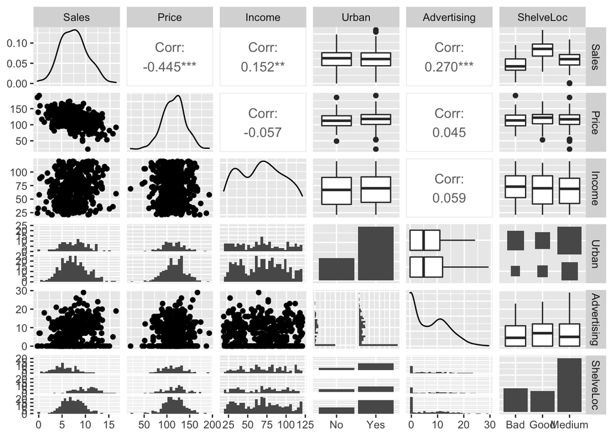

```r
ggpairs(data)
```

It is visible that price has a negative correlation with sales. Income has a positive correlation with sales. Income has a low negative correlation with price. advertising has a positive correlation with sales, price and income. Most of the sales lies between 5 to 10 and mostly has a normal distribution.The values of Urban are evenly distributed for both no and yes when compared with income. Advertising and shelveLoc have a inverse relation. Shelveloc has almost same mean for bad, good and medium when compared with income. Urban plots are bivariate and shelveloc has trivariate plots.

```r
attach(Carseats)
lm(Sales ~ Price + Income + Urban + Advertising + ShelveLoc)
```

```
##
## Call:
## lm(formula = Sales ~ Price + Income + Urban + Advertising + ShelveLoc)
##
## Coefficients:
##     (Intercept)            Price           Income         UrbanYes
##        10.27293         -0.05724          0.01364          0.19689
##     Advertising    ShelveLocGood  ShelveLocMedium
##         0.10506          4.85654          1.91184
```

```r
lreg_car <- lm(Sales ~ Price + Income + Urban + Advertising + ShelveLoc)
summary(lreg_car)
```

```
##
## Call:
## lm(formula = Sales ~ Price + Income + Urban + Advertising + ShelveLoc)
##
## Residuals:
##     Min      1Q  Median      3Q     Max
## -5.1957 -1.1420  0.0375  1.0624  4.1492
##
## Coefficients:
##                  Estimate Std. Error t value Pr(>|t|)
## (Intercept)     10.272928   0.533930  19.240  < 2e-16 ***
## Price           -0.057238   0.003690 -15.513  < 2e-16 ***
## Income           0.013643   0.003126   4.364 1.64e-05 ***
## UrbanYes         0.196891   0.191522   1.028    0.305
## Advertising      0.105056   0.013141   7.994 1.47e-14 ***
## ShelveLocGood    4.856543   0.260412  18.649  < 2e-16 ***
## ShelveLocMedium  1.911844   0.213703   8.946  < 2e-16 ***
## ---
## Signif. codes:  0 '***' 0.001 '**' 0.01 '*' 0.05 '.' 0.1 ' ' 1
##
## Residual standard error: 1.736 on 393 degrees of freedom
## Multiple R-squared:  0.6278, Adjusted R-squared:  0.6221
## F-statistic: 110.5 on 6 and 393 DF,  p-value: < 2.2e-16
```

$$Y \sim X\beta_0 + X\beta_1 + X\beta_2 + X\beta_3 + X\beta_4 + \epsilon$$
Leaving the variable Urban other variable can be used to reject the null hypothesis. The p values of other variables is less than the significance level of 0.001. we have sufficient evidence to reject null hypothesis at 0.1 percent significance.Shelvelocgood is the most significant variable